Trabajo 2. Decisión Multicriterio Teoría de la decisión Marta Venegas Pardo 11/9/2021

```r
source("ScriptsNecesarios/teoriadecision_funciones_multicriterio.R")
#source("ScriptsNecesarios/teoriadecision_funciones_multicriterio_diagram.R")
source("ScriptsNecesarios/teoriadecision_funciones_multicriterio_utiles.R")
```

# 1 Enunciado

Luis hace su último año de residencia de anestesia en el hospital General Universitario de Ciudad Real, pero tiene que ir un mes a trabajar en el hospital Asepeyo en un pueblo a las afueras de Madrid, por lo que va a vivirá durante un mes en Madrid Capital, pero debe ir y volver a Ciudad Real 3 veces para hacer guardias.

Debe elegir un medio de transporte entre tres posibles alternativas:

- Alquilar una moto en Madrid para ese mes, que sería un total de 220 euros más gasolina.
- Compar un patinete eléctrico (200 euros) y sacar un bono de metro que le permita ir y volver al hospital desde el centro por 28 euros.

Para estas dos opciones, necesitaría sacar un abono de 10 viajes de Renfe para ir y volver a Ciudad Real, por un importe de 195 euros.

Para tomar una decisión, Luis ha considerado tres criterios:

- Seguridad
- Precio
- Condiciones de viaje
  - Tiempo invertido en el/los trayecto
  - Meteorología (frío/lluvia/nieve)

Dentro de las condiciones de viaje, considera que es importante considerar el tiempo que tardaría en llegar al hospital en función del medio de transporte elegido y las condiciones meteorológicas, que le harían tener que cambiar su itinerario.

- Matriz comparación entre Criterios

[output not shown]

- Matriz de ponderación de importancias dentro del criterio CONDICIONES DEL VIAJE

| Condiciones | Tiempo(trayect) | Meteorología |
| --- | --- | --- |
| Tiempo(trayect) | 1 | 7 |
| Meteorología | 1/7 | 1 |

- Matriz comparación entre Alternativas según Criterios

| Seguridad | Moto | Patín | Coche |
| --- | --- | --- | --- |
| Moto | 1 | 1/3 | 1/7 |
| Patín | 3 | 1 | 1/5 |
| Coche | 7 | 5 | 1 |

[output not shown]

- Matriz comparación entre Alternativas según Subcriterios

| Meteorología | Moto | Patín | Coche |
| --- | --- | --- | --- |
| Moto | 1 | 1 | 1/7 |
| Patín | 1 | 1 | 1/7 |
| Coche | 7 | 7 | 1 |

| Tiempo | Moto | Patín | Coche |
| --- | --- | --- | --- |
| Moto | 1 | 7 | 2 |
| Patín | 1/7 | 1 | 1/5 |
| Coche | 1/2 | 5 | 1 |

Para conseguir una ordenación de las alternativas y obtener la mejor, tenemos la siguiente información

El decisor nos ha proporcionado los siguientes pesos preferenciales: W=(0.4,0.2,0.4)

Como ya sabíamos, para tomar una decisión, Luis ha considerado tres criterios relevantes para tomar la decisión de clasificar los tres medios de transporte para viajar durante ese mes que está en Madrid.

- Seguridad (maximizar)
- Precio (minimizar)
- Condiciones de viaje (maximizar)

Ahora encontramos una tabla con información relevante proporcionada por Luis para resolver el problema.

| Criterio | Min/Max | Tipo | Parámetros | Parámetros |
| --- | --- | --- | --- | --- |
| Seguridad | Max | III | q=1 |  |
| Precio | Min | I | q=10 | p=30 |
| Condiciones de viaje | Max | II | s=3 | p=5 |

La matriz de decisión viene recogida en la siguiente tabla:

[output not shown]

Utilizar los métodos Electre y Promethee para ordenar las alternativas y obtener la mejor decisión.

# 2 Solución con paquete AHP

```r
#devtools::install_github("gluc/ahp", build_vignettes = TRUE)
# ahp::RunGUI()
 #install.packages("devtools")
devtools::install_github("gluc/ahp", build_vignettes = TRUE)
library(ahp)
MovilidadAHP = Load("trabajo2TD.ahp")
```

Para evitar mensajes no deseados, añadimos la siguiente función:

```r
Visualize_mej = function(modeloahp) {
    sink("temp.txt")
    s1 = Visualize(modeloahp)
    sink()
    unlink("temp.txt")
    s1
}
```

```r
#Visualize(dtMio)
Visualize_mej(MovilidadAHP )
```

[interactive chart not shown]

### 2.0.1 Locales. Criterios/Subcriterios y Alternativas

```r
ahp::Calculate(MovilidadAHP )
ahp::AnalyzeTable(MovilidadAHP , sort="orig",variable="priority")
```

|  | Priority | Moto | PatinElectrico | Coche | Inconsistency |
| --- | --- | --- | --- | --- | --- |
| Decidir un medio de transporte en Madrid | 100.0% |  |  |  | 9.5% |
| Seguridad | 79.6% | 8.8% | 19.5% | 71.7% | 9.0% |
| CondicionesViaje | 12.1% |  |  |  | 0.0% |
| TiempoTrayecto | 87.5% | 59.2% | 7.5% | 33.3% | 1.3% |
| Meteorologia | 12.5% | 11.1% | 11.1% | 77.8% | 0.0% |
| Precio | 8.3% | 8.1% | 18.8% | 73.1% | 6.2% |

### 2.0.2 Tabla para la interpretación. Pesos globales

```r
ahp::AnalyzeTable(MovilidadAHP , sort="orig")
```

|  | Weight | Moto | PatinElectrico | Coche | Inconsistency |
| --- | --- | --- | --- | --- | --- |
| Decidir un medio de transporte en Madrid | 100.0% | 14.1% | 18.0% | 67.9% | 9.5% |
| Seguridad | 79.6% | 7.0% | 15.5% | 57.1% | 9.0% |
| CondicionesViaje | 12.1% | 6.4% | 1.0% | 4.7% | 0.0% |
| TiempoTrayecto | 10.6% | 6.3% | 0.8% | 3.5% | 1.3% |
| Meteorologia | 1.5% | 0.2% | 0.2% | 1.2% | 0.0% |
| Precio | 8.3% | 0.7% | 1.6% | 6.1% | 6.2% |

Conclusiones:

Explicación de los pesos globales:

# 3 Método Promethee

## 3.1 Promethee I

```r
tabdec.X = multicriterio.crea.matrizdecision(
  c(80,-(220+195),90,
   350,-(200+28+195),110,
   450,-(200+100),90),
  numalternativas=3,
  numcriterios=3,
  v.nombresalt=c("Moto","Patinete E","Coche"),
  v.nombrescri = c("Seguridad","Precio","Condiciones")

)
tabdec.X
```

```
##            Seguridad Precio Condiciones
## Moto              80   -415          90
## Patinete E       350   -423         110
## Coche            450   -300          90
```

```r
wi<-c(2/5,1/5,2/5)
# Le da más importancia a la seguridad y a las condiciones del viaje que al precio
salM= multicriterio.metodo.promethee_i(
  tabdec.X,
  pesos.criterios = wi, # porque son 6 criterios, LOS PESOS DEBEN SUMAR 1
  tab.fpref=matrix(c( 2,1, 0, 0, # nro ,qi,pi,si
                      3,10,30,0,
                      1,3, 5, 0),
                   ncol=4,
                   byrow=TRUE))

  tab.fpref=matrix(c( 2,1, 0, 0, # nro ,qi,pi,si
                      3,10,30,0,
                      1,3, 5, 0),ncol=4,
                   byrow=TRUE)
salM
```

```
## $tabla.indices
##            Moto Patinete E Coche
## Moto        0.0 0.05333333   0.0
## Patinete E  0.8 0.00000000   0.4
## Coche       0.6 0.60000000   0.0
##
## $vflujos.ent
##       Moto Patinete E      Coche
## 0.05333333 1.20000000 1.20000000
##
## $vflujos.sal
##       Moto Patinete E      Coche
##  1.4000000  0.6533333  0.4000000
##
## $tablarelacionsupera
##            Moto Patinete E Coche
## Moto        0.5        0.0   0.0
## Patinete E  1.0        0.5   0.0
## Coche       1.0        1.0   0.5
```

Representar en un grafo:

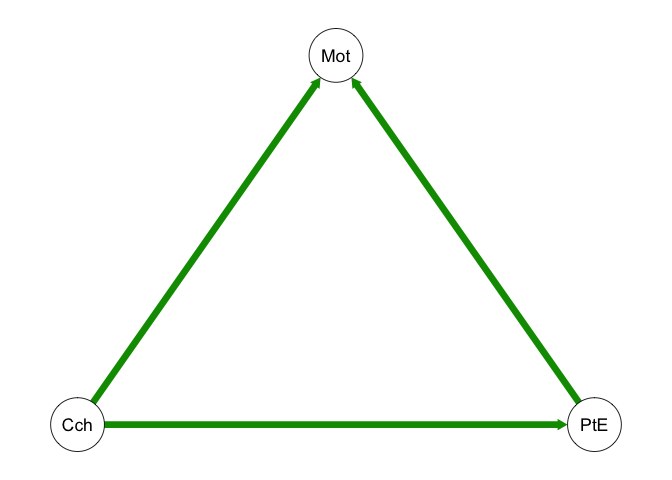

```r
qgraph::qgraph(salM$tablarelacionsupera)
```

Ir en coche domina a todos y el patinete domina a la moto. La moto no domina a ninguna alternativa.

Conclusión: la mejor alternativa es ir en coche, la segunda sería ir en patín eléctrico y por último, ir en moto sería la última alternativa a considerar.

## 3.2 Promethee II

```r
salMPrometheeII= multicriterio.metodo.promethee_ii(
  tabdec.X,
  pesos.criterios = wi, # porque son 6 criterios, LOS PESOS DEBEN SUMAR 1
  tab.fpref=matrix(c( 2,1, 1, 0, # nro ,qi,pi,si
                      3,10,30,0,
                      1,3, 5, 0),
                   ncol=4,
                   byrow=TRUE))

  tab.fpref=matrix(c( 2,1, 1, 0, # nro ,qi,pi,si
                      3,10,30,0,
                      1,3, 5, 0),ncol=3,
                   byrow=TRUE)
salMPrometheeII
```

```
## $tabla.indices
##            Moto Patinete E Coche
## Moto        0.0 0.05333333   0.0
## Patinete E  0.8 0.00000000   0.4
## Coche       0.6 0.60000000   0.0
##
## $vflujos.netos
##       Moto Patinete E      Coche
## -1.3466667  0.5466667  0.8000000
##
## $tablarelacionsupera
##            Moto Patinete E Coche
## Moto        0.5        0.0   0.0
## Patinete E  1.0        0.5   0.0
## Coche       1.0        1.0   0.5
```

Representar en un grafo:

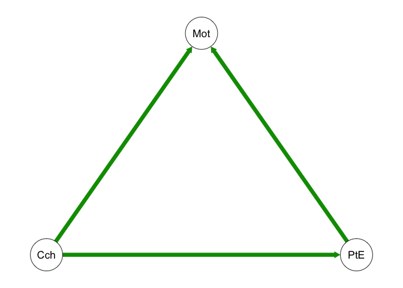

```r
qgraph::qgraph(salMPrometheeII$tablarelacionsupera)
```

De nuevo, ir en coche domina a todos y el patinete domina a la moto. La moto no domina a ninguna alternativa.

```r
order(salMPrometheeII$vflujos.netos,decreasing = T)
```

```
## [1] 3 2 1
```

Me dice que la alternativa 3 (ir en coche) es la mejor, seguido de ir en patín y por último, la moto.

# 4 Método Electre

Método electre:

- D
- Alpha
- Pesos de comparación, podríamos ponerlos todos infinitos

## 4.1 Primera iteración

```r
salElectre=multicriterio.metodoELECTRE_I(tabdec.X,
                      pesos.criterios = c(2/5,1/5,2/5),
                      nivel.concordancia.minimo.alpha = 0.7,
                      no.se.compensan = c(Inf,55,Inf),
                      que.alternativas = TRUE
                                   )
cat("El núcleo es: ",salElectre$nucleo_aprox)
```

```
## El núcleo es:  2 3
```

Es decir, no conseguimos distinguir qué alternativa es mejor, si ir en patinete o en coche.

Representación del grafo

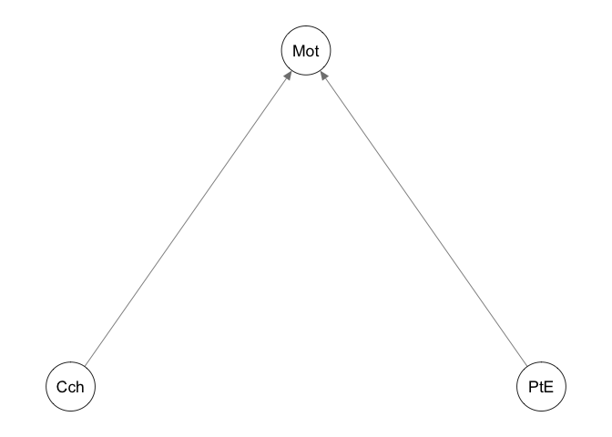

```r
qgraph::qgraph(salElectre$relacion.dominante)
```

Vamos a realizar iteraciones de este método para ver si conseguimos establecer una relación de preferencia entre un método y otro.

## 4.2 Segunda iteración

En la siguiente iteración:

```r
salElectrei2=multicriterio.metodoELECTRE_I(tabdec.X,
                      pesos.criterios = wi,
                      nivel.concordancia.minimo.alpha = 0.7,
                      no.se.compensan = c(Inf,55,Inf),
                      que.alternativas = c(2,3))

salElectrei2$nucleo_aprox
```

```
## Patinete E      Coche
##          1          2
```

El núcleo es el mismo que antes. Tengo que bajar alpha

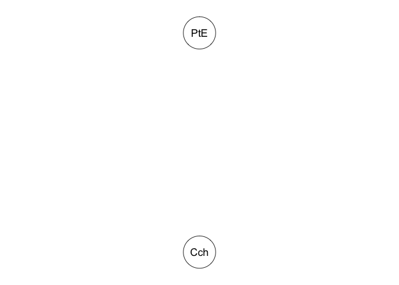

```r
qgraph::qgraph(salElectrei2$relacion.dominante)
```

Ambas alternativas siguen siendo equivalentes.

## 4.3 Tercera iteracción

En la siguiente iteración:

```r
salElectrei3=multicriterio.metodoELECTRE_I(tabdec.X,
                      pesos.criterios = wi,
                      nivel.concordancia.minimo.alpha = 0.6, # 0.68, 0.60
                      no.se.compensan = c(Inf,55,Inf),
                      que.alternativas = c(2,3))

salElectrei3$nucleo_aprox
```

```
## Coche
##     2
```

Ahora, el núcleo es la alternativa 2, es decir: ir en coche.

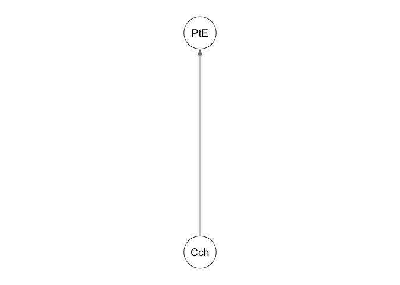

```r
qgraph::qgraph(salElectrei3$relacion.dominante)
```

Por tanto, según el método electre, la mejor alternativa es: IR EN COCHE.

## 4.4 Cálculos en el método electre I La representación de las tables de test con KableExtra

```r
library(dplyr)
library(kableExtra)
library(stringr)
salke = func_ELECTRE_Completo(salElectre)
```

```r
salke$MIndices$KE
```

| Alts | Inds | A1 | A2 | A3 |
| --- | --- | --- | --- | --- |
| A1 | I+ |  | 2 |  |
| A1 | I= | 1,2,3 |  | 3 |
| A1 | I- |  | 1,3 | 1,2 |
| A2 | I+ | 1,3 |  | 3 |
| A2 | I= |  | 1,2,3 |  |
| A2 | I- | 2 |  | 1,2 |
| A3 | I+ | 1,2 | 1,2 |  |
| A3 | I= | 3 |  | 1,2,3 |
| A3 | I- |  | 3 |  |

ELECTRE: Conjunto de Índices

Comentarios respecto a la alternativa 1 A1: Ir en moto

Comentarios respecto A2 y A3:

```r
salke$TConcordancia$KE
```

| Alts | Inds | A1 | A2 | A3 |
| --- | --- | --- | --- | --- |
| A1 | Ijk | 1 | 0.2 | 0.4 |
| A1 | IGjk | NaN | 0.25 | 0 |
| A1 | TC | F | F | F |
| A2 | Ijk | 0.8 | 1 | 0.4 |
| A2 | IGjk | 4 | NaN | 0.6667 |
| A2 | TC | T | F | F |
| A3 | Ijk | 1 | 0.6 | 1 |
| A3 | IGjk | Inf | 1.5 | NaN |
| A3 | TC | T | F | F |

ELECTRE: Test Concordancia

Notación:

- F= NO PASA EL TEST DE CONCORDANCIA
- RESULTADO AZUL: PAREJAS QUE PASAN EL TEST DE CONCORDANCIA

Sólo pasan el test de corcondancia:

- A2SA1: Ir en patín supera a ir en moto
- A3SA1: Ir en coche supera a ir en moto

```r
salke$TDiscordancia$KE
```

| Alts | Inds | A1 | A2 | A3 |
| --- | --- | --- | --- | --- |
| A1 | I- |  | 1,3 | 1,2 |
| A1 | Djk |  | 270(Inf),20(Inf) | 370(Inf),115(55) |
| A1 | TD | T | T | F |
| A2 | I- | 2 |  | 1,2 |
| A2 | Djk | 8(55) |  | 100(Inf),123(55) |
| A2 | TD | T | T | F |
| A3 | I- |  | 3 |  |
| A3 | Djk | NA | 20(Inf) |  |
| A3 | TD | T | T | T |

ELECTRE: Test Discordancia: vd=(Inf,55,Inf)

Notación:

- F= NO PASA EL TEST DE DISCORDANCIA
- RESULTADO AZUL: PAREJAS QUE PASAN EL TEST DE DISCORDANCIA
- LA DIAGONAL SE SUPERA ENTERA PERO NO VA A INFLUIR

Las alternativas que pasaban el test de concordancia también pasan el de discordancia, son:

- A2SA1: Ir en patín supera a ir en moto
- A3SA1: Ir en coche supera a ir en moto

```r
salke$TSuperacion$KE
```

| Alts | Inds | A1 | A2 | A3 |
| --- | --- | --- | --- | --- |
| A1 | TC | F | F | F |
| A1 | TD | T | T | F |
| A1 | RSup | F | F | F |
| A2 | TC | T | F | F |
| A2 | TD | T | T | F |
| A2 | RSup | T | F | F |
| A3 | TC | T | F | F |
| A3 | TD | T | T | T |
| A3 | RSup | T | F | F |

ELECTRE: Relación Superación: alpha = 0.7, vd=(Inf,55,Inf)

CONCLUSIÓN:

- A2SA1: Ir en patín supera a ir en moto
- A3SA1: Ir en coche supera a ir en moto

```r
salke$Grafo
```

```
##   De A
## 1  2 1
## 2  3 1
```

[figure not shown]

```r
qgraph::qgraph(salke$Grafo)
```

El núcleo

```r
salke$Nucleo
```

```
## Patinete E      Coche
##          2          3
```

# 5 Análisis paramétrico ó de sensibilidad. Método axiomático de Arrow y Raymond

Vamos a estudiar como cambian las ordenaciones de las alternativas para los distintos valores de $\alpha$.

La matriz de decisión es la siguiente:

```r
tabdec.X = multicriterio.crea.matrizdecision(
  c(80,-(220+195),90,
   350,-(200+28+195),110,
   450,-(200+100),90),
  numalternativas=3,
  numcriterios=3,
  v.nombresalt=c("Moto","Patinete E","Coche"),
  v.nombrescri = c("Seguridad","Precio","Condiciones")

)
tabdec.X
```

```
##            Seguridad Precio Condiciones
## Moto              80   -415          90
## Patinete E       350   -423         110
## Coche            450   -300          90
```

```r
intalpha = seq(1,2,0.1)
sols = vector("list",length(intalpha))
for (i in 1:length(intalpha)) {
  pej7_i = tabdec.X
  pej7_i[1,] = pej7_i[1,] * intalpha[i]
  sej7_i = multicriterio.metodoaxiomatico.ArrowRaymond(pej7_i)
  sols[[i]] = sej7_i$alternativasordenadas
}
sols
```

```
## [[1]]
## [1] "Coche"      "Patinete E" "Moto"
##
## [[2]]
## [1] "Coche"      "Patinete E" "Moto"
##
## [[3]]
## [1] "Coche"      "Patinete E" "Moto"
##
## [[4]]
## [1] "Coche"      "Patinete E" "Moto"
##
## [[5]]
## [1] "Coche"      "Patinete E" "Moto"
##
## [[6]]
## [1] "Coche"      "Patinete E" "Moto"
##
## [[7]]
## [1] "Coche"      "Patinete E" "Moto"
##
## [[8]]
## [1] "Coche"      "Patinete E" "Moto"
##
## [[9]]
## [1] "Coche"      "Patinete E" "Moto"
##
## [[10]]
## [1] "Coche"      "Patinete E" "Moto"
##
## [[11]]
## [1] "Coche"      "Patinete E" "Moto"
```

Observamos que la ordenación es siempre la misma, es decir, que independientemente del valor de $\alpha \in [1,2]$, la mejor alternativa va a ser: *Coger el coche*, la segunda ir en patinete eléctrico y por último, ir en moto.

Vamos a estudiar como varía la posición de la alternativa *Coche* en función de los valores de alpha

```r
posiciones_Coche=rep(NA, length(intalpha ))

for(i in 1:length(intalpha )){
  posiciones_Coche[i]=which(sols[[i]]=="Coche")
}

posiciones_Coche
```

```
##  [1] 1 1 1 1 1 1 1 1 1 1 1
```

El coche siempre es la mejor alternativa.

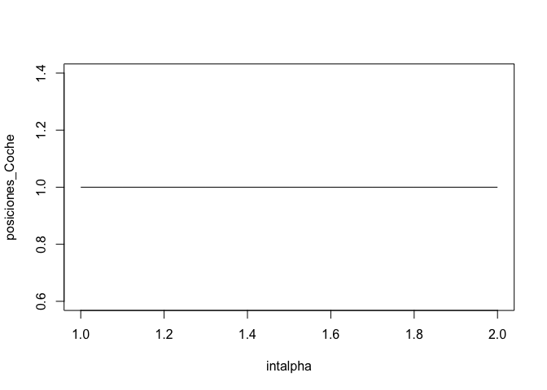

```r
plot(intalpha,posiciones_Coche,type= "l")
```

Siempre ocupa la posición 1.

# 6 Método axiomático de Arrow y Raymond

```r
arrow = multicriterio.crea.matrizdecision(
  c(80,-(220+195),90,
   350,-(200+28+195),110,
   450,-(200+100),90),
  numalternativas=3,
  numcriterios=3,
  v.nombresalt=c("Moto","Patinete E","Coche"),
  v.nombrescri = c("Seguridad","Precio","Condiciones")
)


sal.arrow = multicriterio.metodoaxiomatico.ArrowRaymond(arrow)

# alternativas ordenadas d mejor a peor
sal.arrow$alternativasordenadas
```

```
## [1] "Coche"      "Patinete E" "Moto"
```

```r
sal.arrow
```

```
## $pasos
## $pasos[[1]]
## $pasos[[1]]$Mclasificacion
##            Moto Patinete E Coche
## Moto         NA          1   0.5
## Patinete E  2.0         NA   1.0
## Coche       2.5          2    NA
##
## $pasos[[1]]$max.filas
##       Moto Patinete E      Coche
##        1.0        2.0        2.5
##
## $pasos[[1]]$indices.ordenados
## [1] 1 2 3
##
## $pasos[[1]]$alternativa.sale
## [1] "Moto"
##
##
## $pasos[[2]]
## $pasos[[2]]$Mclasificacion
##            Patinete E Coche
## Patinete E         NA     1
## Coche               2    NA
##
## $pasos[[2]]$max.filas
## Patinete E      Coche
##          1          2
##
## $pasos[[2]]$indices.ordenados
## [1] 1 2
##
## $pasos[[2]]$alternativa.sale
## [1] "Patinete E"
##
##
##
## $alternativasordenadas
## [1] "Coche"      "Patinete E" "Moto"
```

Según este método, la ordenación de las alternativas vuelve a ser la siguiente: 1. Ir en coche 2. Ir en patinete eléctrico 3. Ir en moto

# 7 VERSIONES

## 7.1 Matriz de comparación entre criterios

En la versión 1, teníamos la siguiente matriz de comparación entre criterios:

| Criterios | Seguridad | Condiciones | Precio |
| --- | --- | --- | --- |
| Seguridad | 1 | 9 | 7 |
| Condiciones | 1/9 | 1 | 3 |
| Precio | 1/7 | 1/3 | 1 |

Con estos datos, obtenemos una inconsistencia del 19.6%. Por ello, y trás haber revisado los pesos, hemos obtenido la siguiente matriz de comparación:

| Criterios | Seguridad | Condiciones | Precio |
| --- | --- | --- | --- |
| Seguridad | 1 | 9 | 7 |
| Condiciones | 1/9 | 1 | 2 |
| Precio | 1/7 | 1/2 | 1 |

Ahora la inconsistencia es menor del 10%

## 7.2 Matriz de comparación entre alternativas según criterios

En el criterio *seguridad*, teníamos una inconsistencia del 9% inicialmente, con la siguiente matríz de comparaciones:

| Seguridad | Moto | Patín | Coche |
| --- | --- | --- | --- |
| Moto | 1 | 1/3 | 1/7 |
| Patín | 3 | 1 | 1/5 |
| Coche | 7 | 5 (4*) | 1 |

Por tanto, cambiando la matriz obtenemos una inconsistencia del 5.1%:

| Seguridad | Moto | Patín | Coche |
| --- | --- | --- | --- |
| Moto | 1 | 1/3 | 1/7 |
| Patín | 3 | 1 | 1/4 |
| Coche | 7 | 4 | 1 |

## 7.3 Método electre

Inicialmente, con unos pesos $w_i=(0.5,0.25,0.25$ y aplicando el método Electre, directamente en la primera iteracción obteníamos que el núcleo era la altertativa: *ir en coche*. Esto ocurría a pesar de probar con distintos valores iniciales de $\alpha$. Por ello, probamos con los pesos $w_i=(0.4,0.3,0.3$ y seguía ocurriendo lo mismo. Finalmente, elegimos los pesos siguientes $w_i=(0.4,0.2,0.4$, donde al menos teníamos que realizar dos iteraciones para poder elegir una alternativa.